# -INTRODUCTION- (20 pts possible)

## Scientific question: (5 pts)

Does a mutation in the the down syndrome cell adhesion molecule-like protein 1 homolog gene (DSCAML1), cause a similar hindrance in lamina-specific synaptic connections in the retina for humans and mice?

### Background on scientific question: (5 pts)

In different human chromosomes, there are different neuronal cell adhesion molecules. There is DSCAM which is on chromosome 21 and there is DSCAML1 on chromosome 11. This molecule works to repell cells from eachtoher after attaching. I am interested in how DSCAML1 in humans compares to the DSCAML1 of mice. In mice, DSCAML serves in neurodevelopmental functions all of which include synaptic adhesion, self avoidance and anxon guidance.

## Scientific hypothesis: (5 pts)

If the DSCAML1 gene is mutant, then there will be retinal synaptic connection lost for humans and mice

# -LOADING IN PACKAGES- (15 pts possible)

## Definition of each packages: (10 pts) <-- Shown below

### Correctly loading all of the packages (5 pts) <-- Shown in code

## ~ Bio Package: ~

Biopython is a large collection of modules that contains multiple tools available to compute biological information.

### Align (Bio sub-package):

Calling the "align" method places two sequences as arguments in order to identify regions of similarity.

#### ClustalwCommandline (Sub-sub package for align)

##### Note: Import using this code: from Bio.Align.Applications import ClustalwCommandline

This is used for carrying out automatic multiple alignment sequences; whether they be nucleotide or amino acid sequences

#### MafftCommandline (Sub-sub package for align)

##### Note: Import using this code: from Bio.Align.Applications import MafftCommandline

Command line wrapper for the multiple alignment program MAFFT.

### AlignIO (Bio sub-package):

This package deals with files that contain one ore more sequence alignments

### SeqIO (Bio sub-package):

This package (SeqIO) stands for Sequence Input/Output. It only deals with sequences as SeqRecord objects.

### Seq (Bio sub-package):

This sub-package provides objects to represent sequences with alphabetical letters

## ~ Bio.Blast Package: ~

This is a package that has code that works with the inputs and outputs of the BLAST program

### NCBIWWW (Bio.Blast sub-package):

This package code is used to use the NCBI BLAST server from the internet

## ~ Conda Package: ~

Conda is a source package that is available to multiple different systems. For example, I have a Mac OS system. It is also available for/ runs with Windows and Linux. It is able to install, upload & run packages.

### -c bioconda mafft:

Bioconda is a channel for the conda package that has a repository of recipies that are available within GitHub.

## ~ Logomaker: ~

### Note: Import using this code:

#### import logomaker as logomaker

#### pip install logomaker

Logomaker is a python package that generates customized logos for DNA, RNA or protein sequences

## ~ Numpy: ~

### Note: Import using this code: import numpy as np

This is a python library that is utilized when one is working with large/ multi-dimensional arrays. Mathematical functions are used to operate these arrays/ matricies.

## ~ Pandas: ~

### Note: Import using this code: import pandas as pd

This is a python package used for data analysis/ learning tasks. it is a manipulation tool that is built on the NumPy package that was explained in the above definiton.

## ~ Pyplot: ~

This ia an Application Programing Interface (API) for pythons matplotlib

### Note: Import using this code: import matplotlib.pyplot as plt

Matplotlib is a library package for data visualization. We can create graphs, charts and plots. It is a numerical extension of NumPy.

## ~ String IO: ~

### Note: Import using this code: from StringIO import StringIO

String IO is a module that is for an in-memory file-like object. When a String IO object is created, we are to pass the string to the constructor.

# -PERFORMING BIOINFORMATICS ANALYSIS-

Was told it was okay to choose two from the same database/ methods section! So I chose Database 1 and two different methods in relation to the database options.

# Database#1: NCBI --> Method#1 Pairwise

```python
# Import Libraries:
# Align package from Bio
# and Seq package from Bio.Seq
from Bio import Align
from Bio.Seq import Seq
```

```python
# Assign two variables that DSCAML1 gene sequences found in the UniProt website
# Name them:
# MouseDS1 for mouse with down syndrome/contains DSCAML1gene
# and HumanDS1 for human with down syndrome/contains DSCAML1gene
# To read the sequences found on the NCBI Database, use the read function:  .read()

MouseDS1= open("MouseDSCAML1.fasta.txt")
HumanDS1= open("HumanDSCAML1.fasta.txt")
```

```python
# Creating an allignment using the pairwaise function: pairwaise2.align(,)
# Do this for both MouseDS1 and HumanDS1 separately (shown in the next cell of code)


#Can use aligner method
aligner= Align.PairwiseAligner()

# Showing method attributes
print(aligner)
```

[output not shown]

```
Pairwise sequence aligner with parameters
  wildcard: None
  match_score: 1.000000
  mismatch_score: 0.000000
  target_internal_open_gap_score: 0.000000
  target_internal_extend_gap_score: 0.000000
  target_left_open_gap_score: 0.000000
  target_left_extend_gap_score: 0.000000
  target_right_open_gap_score: 0.000000
  target_right_extend_gap_score: 0.000000
  query_internal_open_gap_score: 0.000000
  query_internal_extend_gap_score: 0.000000
  query_left_open_gap_score: 0.000000
  query_left_extend_gap_score: 0.000000
  query_right_open_gap_score: 0.000000
  query_right_extend_gap_score: 0.000000
  mode: global
```

```python
# Import the Libraries needed to do the pairwise sequence alignment
# Use AlignIO package from Bio
# AlignIO description for parsing sequence alignment is in this website: https://www.tutorialspoint.com/biopython/biopython_sequence_alignments.htm
from Bio import AlignIO

# Do the alignment method using the AlignIO.read () function
# Go through the process for both MouseDSL1 and HumanDSL1
# Name properly by adding "alignment" to the end when naming


# MouseDSL1 Alignment

MouseDSCAML1alignment = AlignIO.read(open("MouseDSCAML1.fasta.txt"), "fasta")
print(MouseDSCAML1alignment)
```

```
Alignment with 1 rows and 2053 columns
MWLVTFLLLLDSLHKARPEDVGTSLYFVNDSLQHVTFSSSVGVV...TLV sp|Q4VA61|DSCL1_MOUSE
```

```python
# HumanDSCAML1 Alignment
HumanDSCAML1alignment= AlignIO.read(open("HumanDSCAML1.fasta.txt"), "fasta")
print(HumanDSCAML1alignment)
```

```
Alignment with 1 rows and 2053 columns
MWLVTFLLLLDSLHKARPEDVGTSLYFVNDSLQQVTFSSSVGVV...TLV sp|Q8TD84|DSCL1_HUMAN
```

# Database#1 (Again) --> Method#2: BLAST SEARCH

```python
#Import NCBIWWW from Bio.Blast
from Bio.Blast import NCBIWWW
```

```python
#Read Human sequence data
Human_DSCAML1Sequence_data= open("Human_DSCAMLUNIPROT.txt").read()
Human_DSCAML1Sequence_data
```

```
'>sp|Q8TD84|DSCL1_HUMAN Down syndrome cell adhesion molecule-like protein 1 OS=Homo sapiens OX=9606 GN=DSCAML1 PE=1 SV=2\nMWLVTFLLLLDSLHKARPEDVGTSLYFVNDSLQQVTFSSSVGVVVPCPAAGSPSAALRWY\nLATGDDIYDVPHIRHVHANGTLQLYPFSPSAFNSFIHDNDYFCTAENAAGKIRSPNIRVK\nAVFREPYTVRVEDQRSMRGNVAVFKCLIPSSVQEYVSVVSWEKDTVSIIPEHRF…
```

```python
#Run Mouse sequence data
Mouse_DSCAML1Sequence_data= open("Mouse_DSCAMLUNIPROT.txt").read()
Mouse_DSCAML1Sequence_data
```

```
'>sp|Q4VA61|DSCL1_MOUSE Down syndrome cell adhesion molecule-like protein 1 homolog OS=Mus musculus OX=10090 GN=Dscaml1 PE=1 SV=2\nMWLVTFLLLLDSLHKARPEDVGTSLYFVNDSLQHVTFSSSVGVVVPCPAAGSPSAALRWY\nLATGDDIYDVPHIRHVHANGTLQLFPFSPSAFNSFIHDNDYFCTAENAAGKIRSPNIRIK\nAVFREPYTVRVEDQRSMRGNVAVFKCLIPSSVQEYVSVVSWEKDT…
```

```python
#Import SeqIO from Bio
from Bio import SeqIO

#Create a record.id for Humans
Humanseq_record = next(SeqIO.parse(open('HumanDSCAML1.fasta.txt'),'fasta'))
Humanseq_record.id

Humanseq_record.seq
```

```
Seq('MWLVTFLLLLDSLHKARPEDVGTSLYFVNDSLQQVTFSSSVGVVVPCPAAGSPS...TLV')
```

```python
#Import SeqIO from Bio
from Bio import SeqIO

#Create a record.id for Mouse
Mouseseq_record = next(SeqIO.parse(open('MouseDSCAML1.fasta.txt'),'fasta'))
Mouseseq_record.id

Mouseseq_record.seq
```

```
Seq('MWLVTFLLLLDSLHKARPEDVGTSLYFVNDSLQHVTFSSSVGVVVPCPAAGSPS...TLV')
```

```python
Humanresult_handle=NCBIWWW.qblast("blastp","nt", Humanseq_record.seq)
Humanresult_handle
```

```
<_io.StringIO at 0x7fa629c9ab80>
```

```python
Mouseresult_handle=NCBIWWW.qblast("blastp","nt", Mouseseq_record.seq)
Mouseresult_handle
```

```
<_io.StringIO at 0x7fa629c9a820>
```

# Making a sequence logo

```python
import numpy as np
import pandas as pd
import matplotlib.pyplot as plt
%matplotlib inline
plt.ion()

import logomaker as lm
```

```python
with lm.open_example_datafile('HumanDSCAML1ss_sequences.txt', print_description=False) as f:
    raw_seqs = f.readlines()
raw_seqs[10:20]
```

[output not shown]

```python
#Install -c bioconda mafft from the Conda system-Package
```

```python
conda install -c bioconda mafft
```

```
Solving environment: done

# All requested packages already installed.
```

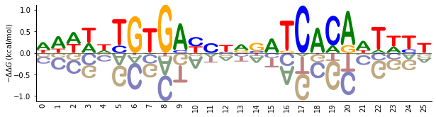

```python
# NOTE: This is not for my Humans vs Mouse DSCAML1 gene! Here is how you would do code for creating a sequence logo for he DNA binding specificity of CRP
#This was shown on the Logomaker website: https://logomaker.readthedocs.io/en/latest/#tareen2019

#Import proper package
import matplotlib.pyplot as plt
import logomaker as logomaker

#Load matrix?
crp_df = -logomaker.get_example_matrix('crp_energy_matrix',
                                        print_description=False)

#create logo object
crp_logo = logomaker.Logo(crp_df,
                          shade_below=.5,
                          fade_below=.5,
                          font_name='Arial Rounded MT Bold')

# style using Logo methods
crp_logo.style_spines(visible=False)
crp_logo.style_spines(spines=['left', 'bottom'], visible=True)
crp_logo.style_xticks(rotation=90, fmt='%d', anchor=0)

# style using Axes methods
crp_logo.ax.set_ylabel("$-\Delta \Delta G$ (kcal/mol)", labelpad=-1)
crp_logo.ax.xaxis.set_ticks_position('none')
crp_logo.ax.xaxis.set_tick_params(pad=-1)

# style and show figure
crp_logo.fig.show()
```

#### My attempt at sequence logo making

```python
pip install logomaker
```

```python
from Bio.Align.Applications import ClustalwCommandline
in_file = "HumanDSCAML1.fasta.txt"
Humanclustalw_cline = ClustalwCommandline("clustalw2", infile=in_file)
print(Humanclustalw_cline)
```

```
clustalw2 -infile=HumanDSCAML1.fasta.txt
```

```python
in_file = "MouseDSCAML1.fasta.txt"
Mouseclustalw_cline = ClustalwCommandline("clustalw2", infile=in_file)
print(Mouseclustalw_cline)
```

```
clustalw2 -infile=MouseDSCAML1.fasta.txt
```

```python
from Bio.Align.Applications import MafftCommandline

mafft_exe = "/opt/local/mafft"
in_file = "HumanDSCAML1.fasta.txt"
mafft_cline = MafftCommandline(mafft_exe, input=in_file)
print(mafft_cline)
```

```
/opt/local/mafft HumanDSCAML1.fasta.txt
```

```python
mafft_exe = "/opt/local/mafft"
in_file = "MouseDSCAML1.fasta.txt"
mafft_cline = MafftCommandline(mafft_exe, input=in_file)
print(mafft_cline)
```

```
/opt/local/mafft MouseDSCAML1.fasta.txt
```

```python
stdout, stderr = mafft_cline()
from StringIO import StringIO
from Bio import AlignIO
align = AlignIO.read(StringIO(stdout), "fasta")
```

[output not shown]

```python
# useful imports
import numpy as np
import pandas as pd
import matplotlib.pyplot as plt
%matplotlib inline
plt.ion()

import logomaker
```

```python
# logomaker method to load example matrices
MouseDSCAML1df = logomaker.get_example_matrix('MouseDSCAML1.fasta.txt')
MouseDSCAML1df.head()
```

[output not shown]

```python
HumanDSCAML1df= logomaker.get_example_matrix('HumanDSCAML1ss_sequences.txt')
HumanDSCAML1df.head()
```

[output not shown]

```python
logo = logomaker.Logo(HumanDSCAML1df, font_name = 'Arial Rounded MT Bold')
```

[output not shown]

```python
logo = logomaker.Logo(MouseDSCAML1df, font_name = 'Arial Rounded MT Bold')
```

[output not shown]

# 3D Protein measurements

The Process to get the PYMOL images for each DSCAML1 (both mouse and human) protein, I... 1) went to the reactome database

2) typed in DSCAML1

3) marked "Homo sapians" (human) and made sure to mark "Mus musculus" (mouse) to filter results to my wanted protein

4) For homo sapians, I clicked on the protein DSCAML1, scrolled to "external reference" and clicked the UniProt link. I then clicked "Structure" and downloaded the AlphaFold PDB. I changed this color to a raspberry red so that I could easily identify which was which (human vs mouse). Then I went to file, save image and placed it into my jupyter notebook files.

5) I did the same process for the Mus musculus. I made the color a cyanne blue.

Below are images of the structures.

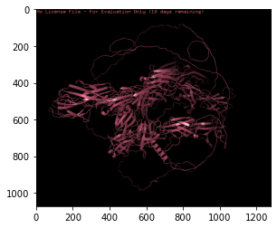

```python
#Import proper packages
import matplotlib.pyplot as plt
import matplotlib.image as mpimg

#Show image for HUMANS
HumanDSCAML1img = mpimg.imread('HumanDSCAML1.png')
imgplot = plt.imshow(HumanDSCAML1img)
plt.show()
```

```python
# or you can do it this way
# this way will open the image in the mac's "preview" app
from PIL import Image

HumanDSCAML1image = Image.open('HumanDSCAML1.png')
HumanDSCAML1image.show()
```

You should get this image for HumanDSCAML1:

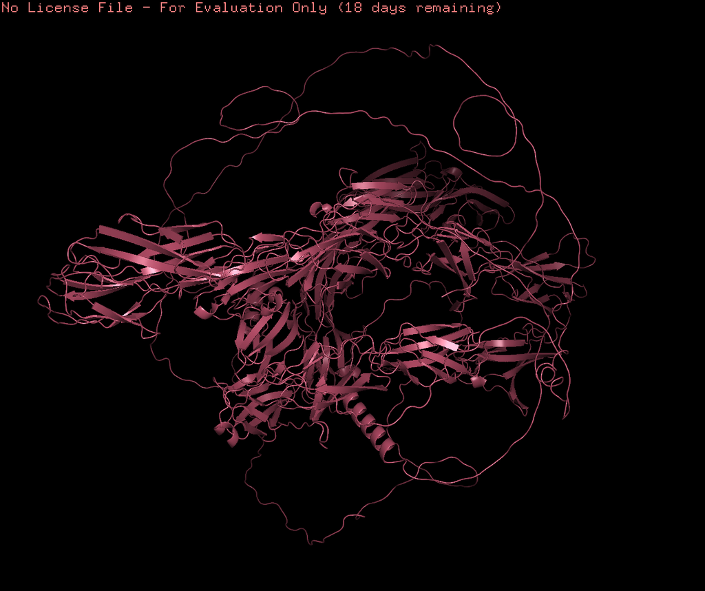

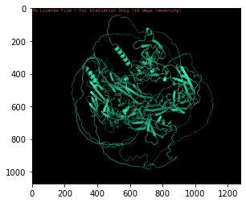

```python
#Show image for Mouse
MouseDSCAML1img = mpimg.imread('MouseDSCAML1.png')
imgplot = plt.imshow(MouseDSCAML1img)
plt.show()
```

```python
# or you can do it this way
# this way will open the image in the mac's "preview" app
from PIL import Image

MouseDSCAML1image = Image.open('MouseDSCAML1.png')
MouseDSCAML1image.show()
```

You should get this image for MouseDSCAML1:

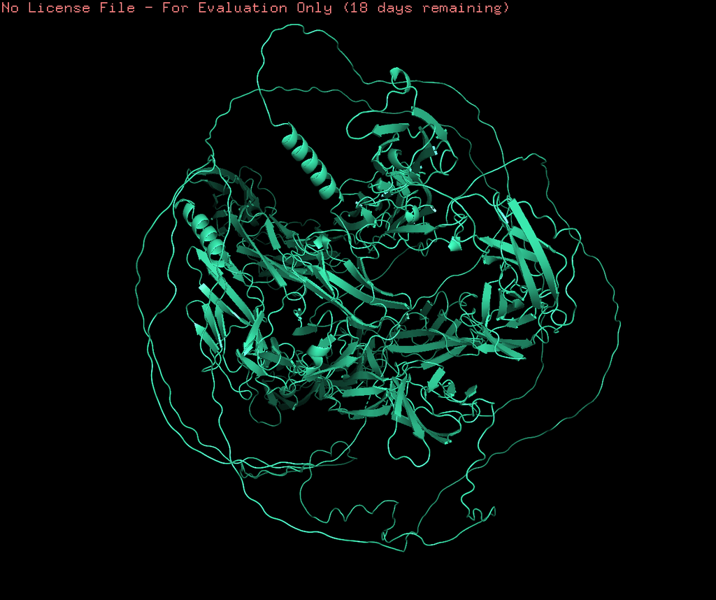

```python
# Use Biopython
# Use this link to use biopython: https://biopython.org/wiki/The_Biopython_Structural_Bioinformatics_FAQ
from Bio.PDB import*
```

```python
conda install -c conda-forge nglview
```

```
Solving environment: done

# All requested packages already installed.
```

```python
#Install nglview
import nglview as nv
```

```python
pip install nglview
```

```python
parser= PDBParser()
```

```python
#Structure for Humans
HumanDSCAML1Structure= parser.get_structure("Human","HumanDSCAML1.png")
```

[output not shown]

```python
view= nv.show_biopython(HumanDSCAML1Structure)
view
```

[output not shown]

```python
compound= HumanDSCAML1Structure.header["compound"]
compound
```

[output not shown]

```python
import numpy
from Bio.PDB.PDBParser import PDBParser

parser = PDBParser()
structure = parser.get_structure("HumanDSCAML1", "HumanDSCAML1.png")

residues = [r for r in structure.get_residues()]        # You don’t need the extensive list traversal you were doing before because there are many get_*() methods
# Calculate the distance between the alpha carbons for a pair of residues
one  = residues[0]["CA"].get_coord()
two = residues[1]["CA"].get_coord()
print('{} - {} = {}'.format(one,two, numpy.linalg.norm(one-two)))
```

[output not shown]

```python
# Structure for Mouse
#Structure for Humans
MouseDSCAML1Structure= parser.get_structure("Mouse","MouseDSCAML1.png")
```

[output not shown]

```python
#View mouse structure
view= nv.show_biopython(MouseDSCAML1Structure)
view
```

[output not shown]

```python
# Compound of mouse structure
compound= MouseDSCAML1tructure.header["compound"]
compound
```

[output not shown]

```python
parser = PDBParser()
structure = parser.get_structure("MouseDSCAML1", "MouseDSCAML1.png")

residues = [r for r in structure.get_residues()]        # You don’t need the extensive list traversal you were doing before because there are many get_*() methods
# Calculate the distance between the alpha carbons for a pair of residues
one  = residues[0]["CA"].get_coord()
two = residues[1]["CA"].get_coord()
print('{} - {} = {}'.format(one,two, numpy.linalg.norm(one-two)))
```

[output not shown]